# Exercise 1

Nicholas Pearson

September 2025

# Part 1

Load the data 1. Load the `hotdog dataset`.

```r
load("hotdog.RData")
```

2. Describe the object `hotdog`:
   - What type of object is it?
   - How many observations does it contain?
   - How many variables?
   - What type of variables?

```r
# Explore the dataset
str(hotdog)
```

```
## 'data.frame':    54 obs. of  4 variables:
##  $ HotDog : int  1 2 3 4 5 6 7 8 9 10 ...
##  $ Type   : Factor w/ 3 levels "Beef","Meat",..: 1 1 1 1 1 1 1 1 1 1 ...
##  $ Calorie: int  186 181 176 149 184 190 158 139 175 148 ...
##  $ Sodium : int  495 477 425 322 482 587 370 322 479 375 ...
```

```r
summary(hotdog)
```

```
##      HotDog           Type       Calorie          Sodium
##  Min.   : 1.00   Beef   :20   Min.   : 86.0   Min.   :144.0
##  1st Qu.:14.25   Meat   :17   1st Qu.:132.0   1st Qu.:362.5
##  Median :27.50   Poultry:17   Median :145.0   Median :405.0
##  Mean   :27.50                Mean   :145.4   Mean   :424.8
##  3rd Qu.:40.75                3rd Qu.:172.8   3rd Qu.:503.5
##  Max.   :54.00                Max.   :195.0   Max.   :645.0
```

3. Compute the following for the variable `Type`
   - Absolute frequency
   - Relative frequency
   - Percentage frequency

```r
# Absolute frequency
abs_freq <- table(hotdog$Type)

# Relative frequency
rel_freq <- prop.table(abs_freq)

# Percentage frequency
perc_freq <- prop.table(abs_freq) * 100

# Display results
abs_freq
```

```
##
##    Beef    Meat Poultry
##      20      17      17
```

```r
rel_freq
```

```
##
##      Beef      Meat   Poultry
## 0.3703704 0.3148148 0.3148148
```

```r
perc_freq
```

```
##
##     Beef     Meat  Poultry
## 37.03704 31.48148 31.48148
```

4. Appropriate graphical representation

What is the best way to visualize the variable Type? Create an appropriate plot.

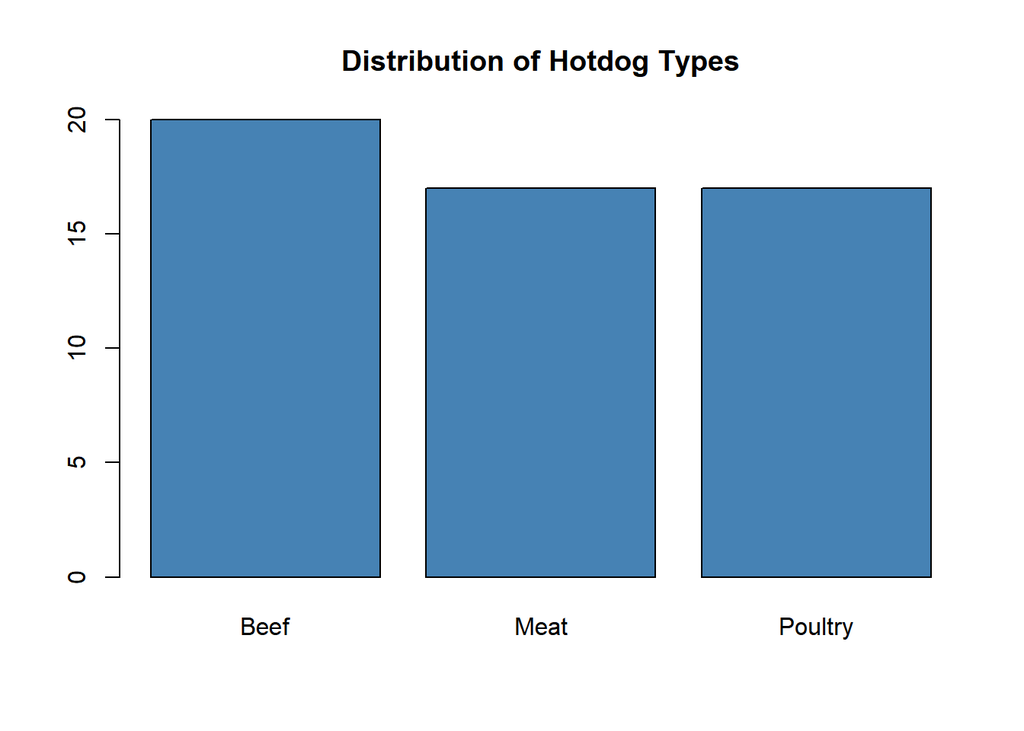

```r
barplot(
  abs_freq,
  main="Distribution of Hotdog Types",
  col="steelblue"
)
```

5. Graphical representation of Calorie Visualize the frequency distribution of the variable Calorie.

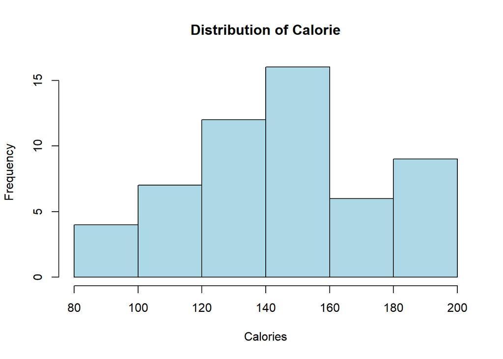

```r
hist(
  hotdog$Calorie,
  main="Distribution of Calorie",
  xlab="Calories",
  col="lightblue"
)
```

6. Frequency distribution in classes

Divide the Calorie variable into the following classes:  
[80,120], (120,140], (140,160], (160,200]

```r
# Define class intervals
breaks <- c(80, 120, 140, 160, 200)
labels <- c("[80,120]", "(120,140]", "(140,160]", "(160,200]")

#Create classes
hotdog$Calorie_classes <- cut(hotdog$Calorie, breaks=breaks, labels=labels, include.lowest=TRUE)

#Display first 10 entries
head(hotdog$Calorie_classes)
```

```
## [1] (160,200] (160,200] (160,200] (140,160] (160,200] (160,200]
## Levels: [80,120] (120,140] (140,160] (160,200]
```

```r
# Compute absolute frequency
abs_freq_cal <- table(hotdog$Calorie_classes)
abs_freq_cal
```

```
##
##  [80,120] (120,140] (140,160] (160,200]
##        11        12        16        15
```

7. Plot barplot for the classes

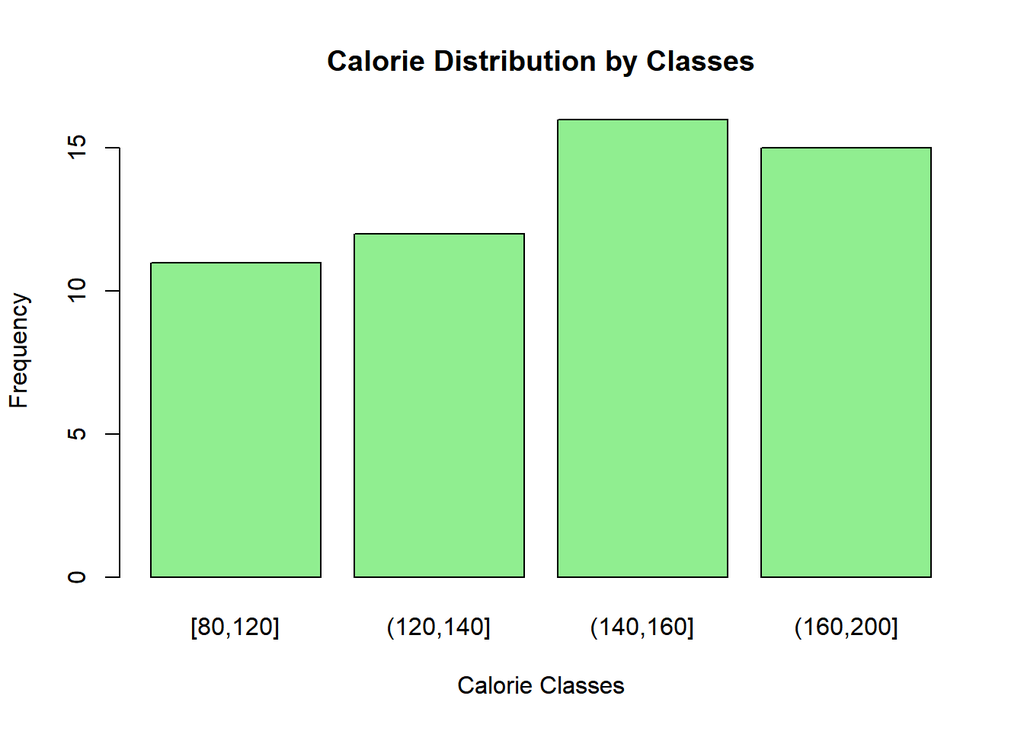

```r
barplot(
  abs_freq_cal,
  main="Calorie Distribution by Classes",
  xlab="Calorie Classes",
  ylab="Frequency",
  col="lightgreen"
)
```

8. Compute densities

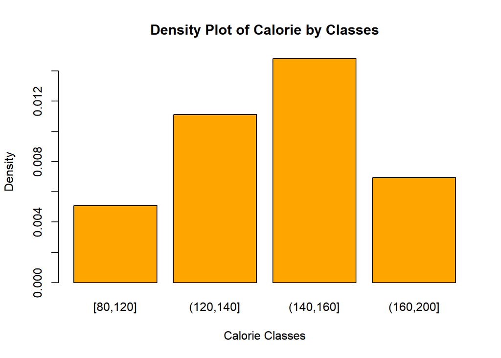

```r
class_widths <- diff(breaks)
densities <- as.numeric(prop.table(abs_freq_cal)) / class_widths
barplot(
  densities,
  names.arg=labels,
  main="Density Plot of Calorie by Classes",
  xlab="Calorie Classes",
  ylab="Density",
  col="orange"
  )
```

9. Play around with interval widths
10. Compare histograms by Type Plot histograms of Calorie for each Type and compare them.

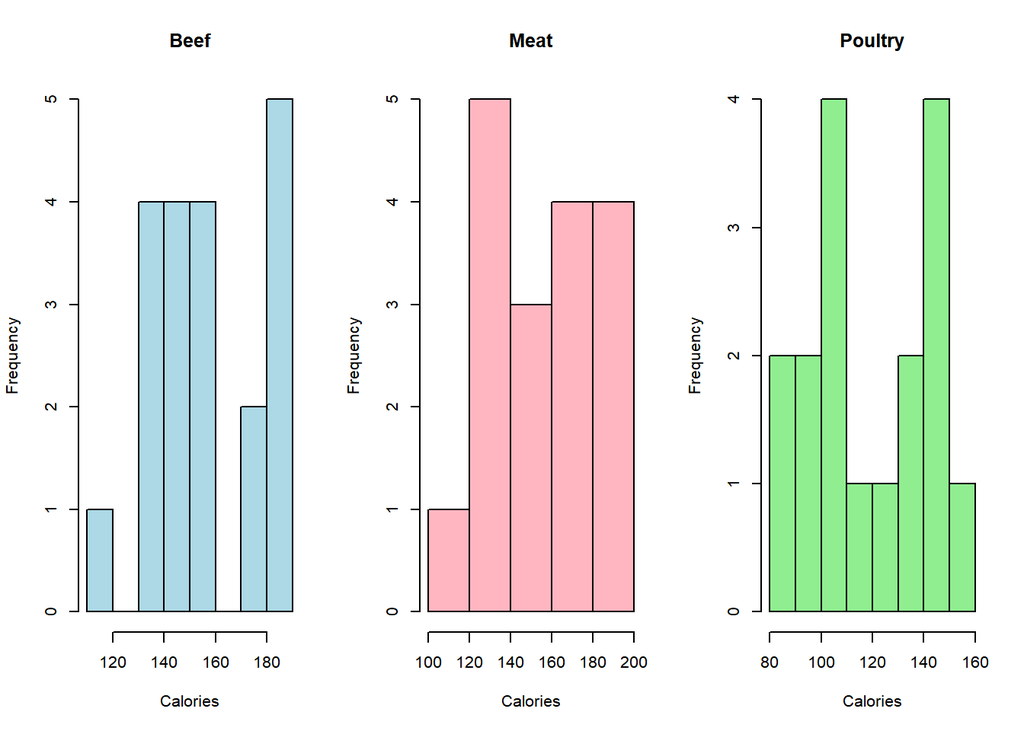

```r
# Example: side-by-side histograms
par(mfrow=c(1,3))
hist(hotdog$Calorie[hotdog$Type=="Beef"], main="Beef", col="lightblue", xlab="Calories")
hist(hotdog$Calorie[hotdog$Type=="Meat"], main="Meat", col="lightpink", xlab="Calories")
hist(hotdog$Calorie[hotdog$Type=="Poultry"], main="Poultry", col="lightgreen", xlab="Calories")
```

# Part 2

1. Using the same dataset, compute the mean, median and variance of Sodium

```r
global_mean <- mean(hotdog$Sodium)
global_med <- median(hotdog$Sodium)
global_var <- var(hotdog$Sodium)

global_mean
```

```
## [1] 424.8333
```

```r
global_med
```

```
## [1] 405
```

```r
global_var
```

```
## [1] 9188.443
```

1.5 Create a custom function that, given an array of values, computes the mean. Crete another one which computes the variance.

```r
custom_mean <- function(values){
  sum <- 0
  N <- length(values)
  for (value in values){
    sum <- sum + value
  }
  return(sum/N)
}

custom_variance <- function(values){
  sum <- 0
  N <- length(values)

  for (value in values){
    sum <- sum + value
  }
  mean <- sum/N

  sum_differences <- 0

  for (value in values){
    tmp <- (value - mean)**2
    sum_differences <- sum_differences + tmp
  }
  return(sum_differences/N)

}
```

2. Create a histogram of Sodium and add 2 lines representing the mean and median

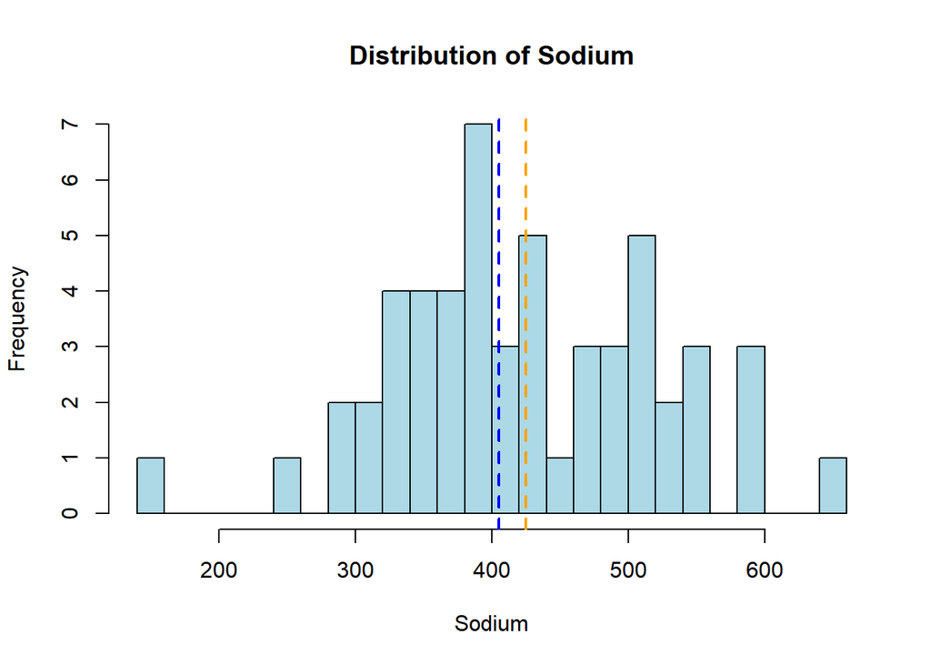

```r
hist(
  hotdog$Sodium,
  breaks = 20,
  main="Distribution of Sodium",
  xlab="Sodium",
  col="lightblue"

)
abline(v = mean(hotdog$Sodium), col = "orange", lwd = 2, lty = 2)
abline(v = median(hotdog$Sodium), col = "blue", lwd = 2, lty = 2)
```

3. Compute mean_by_type, the mean for each type of hotdog. Hint: look at the by() function

```r
mean_by_type = by(hotdog$Sodium, hotdog$Type, mean)
mean_by_type
```

```
## hotdog$Type: Beef
## [1] 401.15
## ------------------------------------------------------------
## hotdog$Type: Meat
## [1] 418.5294
## ------------------------------------------------------------
## hotdog$Type: Poultry
## [1] 459
```

4. Convert the by output to a list

```r
mean_list <- as.list(mean_by_type)
mean_list$Beef
```

```
## [1] 401.15
```

5. Boxplot for each type of hotdog

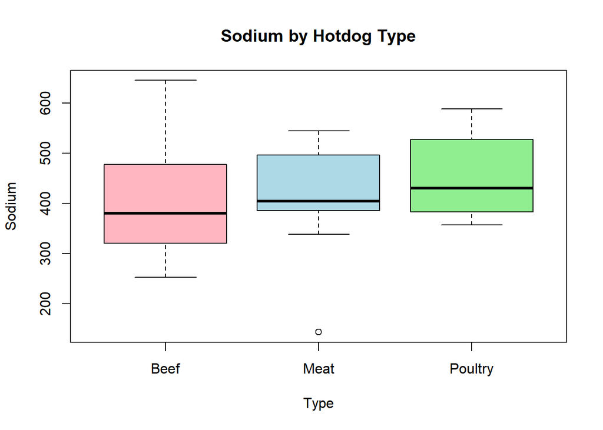

```r
boxplot(
  Sodium ~ Type,
  data=hotdog,
  main="Sodium by Hotdog Type",
  col=c("lightpink","lightblue","lightgreen")
)
```

6. Compute the empirical cumulative distribution function (ECDF) for Sodium Hint: look at the ecdf function

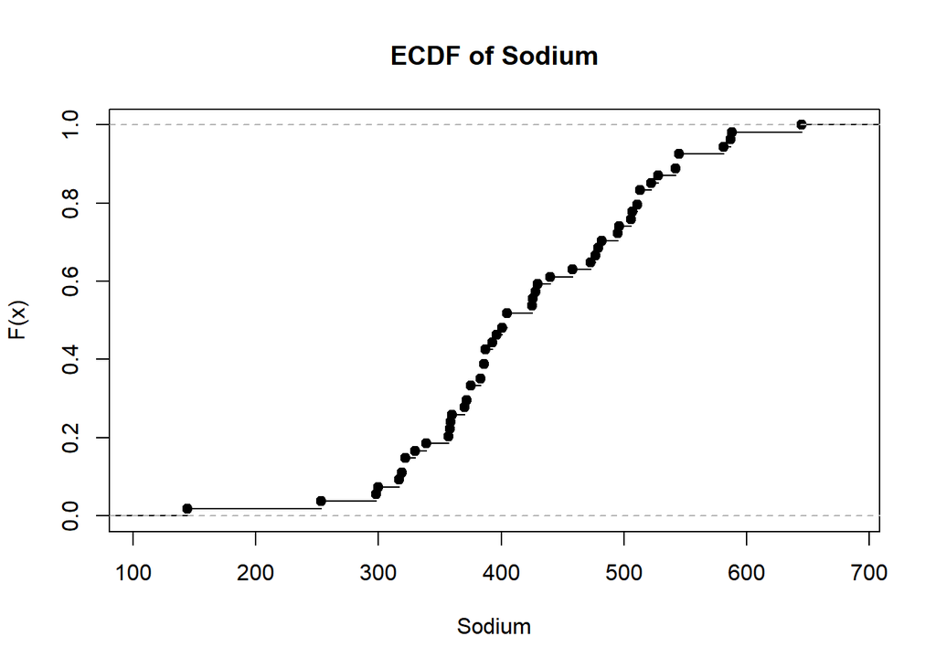

```r
plot(
  ecdf(hotdog$Sodium),
  main="ECDF of Sodium",
  xlab="Sodium",
  ylab="F(x)"
)
```

7. Plot and compare the ECDF for each Type of hotdog

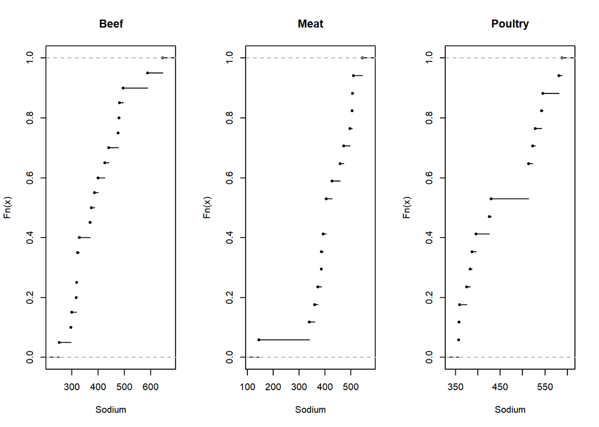

```r
ecdf_beef <- ecdf(hotdog$Sodium[hotdog$Type=="Beef"])
ecdf_meat <- ecdf(hotdog$Sodium[hotdog$Type=="Meat"])
ecdf_poultry <- ecdf(hotdog$Sodium[hotdog$Type=="Poultry"])

par(mfrow=c(1,3))
plot(ecdf_beef, main="Beef", xlab="Sodium")
plot(ecdf_meat, main="Meat", xlab="Sodium")
plot(ecdf_poultry, main="Poultry", xlab="Sodium")
```

8. Compute ECDF for x = 477.5 for each group using ecdf().

```r
x <- 477.5
ecdf_beef(x)
```

```
## [1] 0.75
```

```r
ecdf_meat(x)
```

```
## [1] 0.7058824
```

```r
ecdf_poultry(x)
```

```
## [1] 0.5294118
```

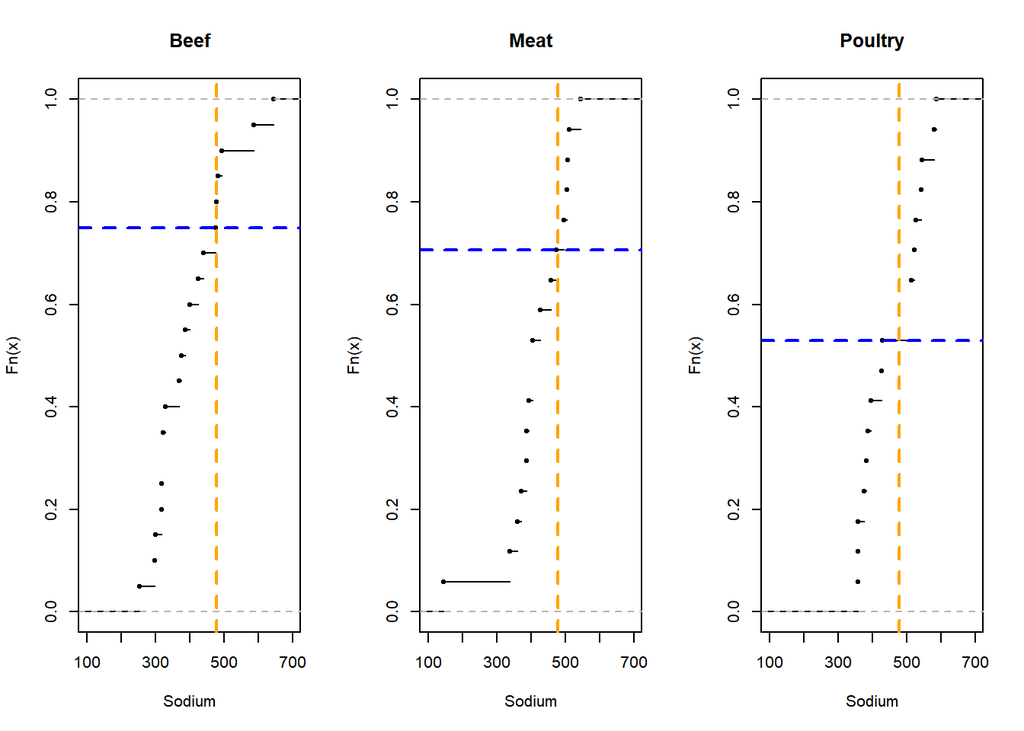

```r
par(mfrow=c(1,3))
plot(ecdf_beef, main="Beef", xlab="Sodium", xlim=c(100,700))
abline(v=x, col = "orange", lwd = 2, lty = 2)
abline(h=ecdf_beef(x), col = "blue", lwd = 2, lty = 2)
plot(ecdf_meat, main="Meat", xlab="Sodium", xlim=c(100,700))
abline(h=ecdf_meat(x), col = "blue", lwd = 2, lty = 2)
abline(v=x, col = "orange", lwd = 2, lty = 2)
plot(ecdf_poultry, main="Poultry", xlab="Sodium", xlim=c(100,700))
abline(h=ecdf_poultry(x), col = "blue", lwd = 2, lty = 2)
abline(v=x, col = "orange", lwd = 2, lty = 2)
```